# Homework 1

## Part Q-17

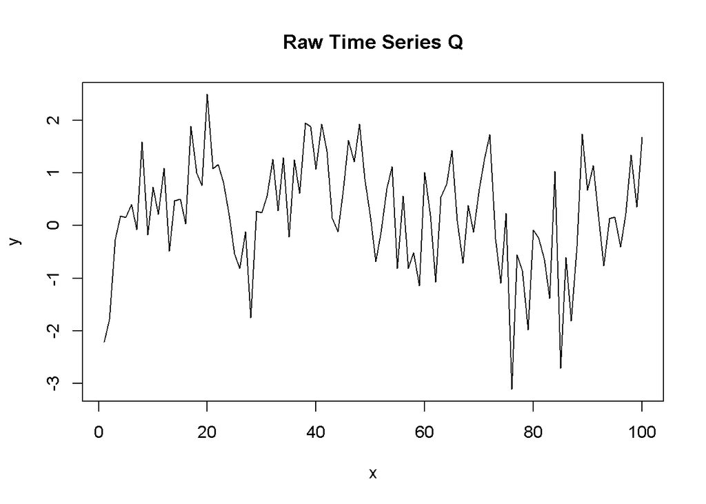

**DGP Guess:** MA(2) where $\psi_1=0.25, \psi_2=0.3$

## Part R-18

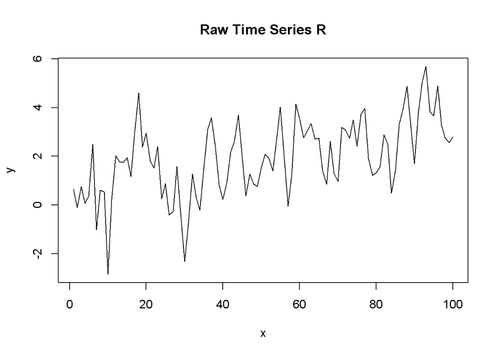

**DGP Guess:** deterministic trend, where $\hat{\beta}=0.0297518$ AND AR(2) where $\phi_1=0.5, \phi_2=-0.2$

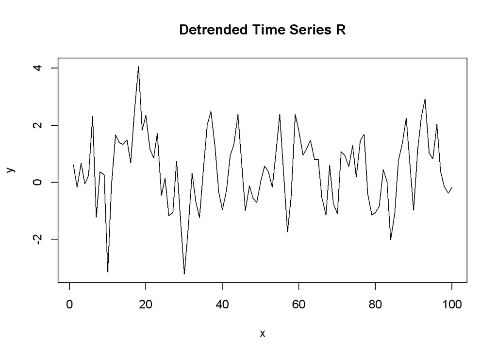

# Question 2

## Part S-1

20: AR(1) of 0.8 100: AR(1) of 0.95 1000: AR(1) of 1 (nonstationary)

As the data increased the magnitude of the autoregressive component seemed to increase as well. With 1000 periods it seems likely that the time series is nonstationary, but I’m much more confident in saying that after seeing 1000 periods rather than only 100.

## Part T-2

20: AR(1) of 0.4 100: AR(1) of 0.75 1000: AR(1) of 0.8

With 1000 periods to look at, my confidence in assessing the actual magnitude of the autoregressive component greatly increased.

## Part U-3

20: AR(1) of 0.9 100: AR(1) of 0.95 1000: AR(2) of 0.95 and -0.2

With 1000 periods of data, I found evidence of a second order autoregressive component. The magnitude of this effect is small enough that there needs to be a substantial amount of data to be able to detect it.

## Part V-4

20: AR(1) of 0.9 100: AR(1) of 0.95 1000: AR(1) of 0.99

With less data, I was concerned that this may be a nonstationary process but wouldn’t have been able to tell. With 1000 periods, I’m more confident that the time series is in fact stationary but has an autoregressive component that is very close to 1.

## Part W-5

20: AR(2) of 0.6 and -0.4 100: AR(1) of 0.9 1000: AR(1) of 1 (nonstationary)

My conclusion drastically changed as I looked at more data. I attributed patterns that were probably noise to the actual data generating process. When looking at more data it became more likely that the process was nonstationary. I don’t think I would have guessed that this was a nonstationary process without a substantial amount of data.